# 決定木アルゴリズム

事例の集計

川田恵介

# 丸暗記の問題

- データへの適合は、データ分析の大部分で活用されている戦略だが、注意も必要
- 非常に複雑なモデルを作ると、データへの適合度は非常に高くなる
- $\iff$ **予測性能** が改善するとは限らない
  - データ固有の特徴を強く反映してしまう
  - $=$ 事例集計が十分にできない

## 事例集計

- “すべての”推定方法で、事例の集計を行う
- 集計を行わない方法も、“日常”的に使われている
  - 例: 丸暗記法

## 例: 賃金予測

```
# A tibble: 4 × 2
   賃金  年齢
  <dbl> <dbl>
1   100    25
2    20    28
3    40    20
4    15    40
```

- 21歳の賃金予測は?

## 例: 賃金予測

```
# A tibble: 4 × 6
   賃金  年齢 丸暗記法 平均法 `データへの適合度:丸暗記` データへの適合度:平均…¹
  <dbl> <dbl>    <dbl>  <dbl>                     <dbl>                   <dbl>
1   100    25      100   43.8                         0                    3164
2    20    28       20   43.8                         0                     564
3    40    20       40   43.8                         0                      14
4    15    40       15   43.8                         0                     827
# ℹ abbreviated name: ¹`データへの適合度:平均法記`
```

## 丸暗記法 VS 平均

- 丸暗記法の方が一般に
  - 複雑な予測モデル
  - データへの適合度が高い
- 現実はおそらく複雑 $X$ の値が異なれば、 $Y$ の値も異なる
  - 丸暗記の方がいいのでは?

## 論点先取り

- 丸暗記のようなデータに適合したモデルは、観察できる要因 $X$ の情報を有効活用できる**可能性**を高める
- 事例集計が不十分に終わり、**観察できない要因の偏り** が弊害をもたらしうる
  - 収集した事例によっては、質の極めて悪い予測モデルが生成される
- 観察できない要素について議論する必要があり、 **抽象的な**枠組みが必要
  - 母集団とサンプリング

# 理想の予測モデル

- 完璧な予測は不可能
- 理想の予測モデルは母平均値関数

## 母集団とサンプリング

- 分析チームは、事例収集から始める
- 直接観察できない巨大な集団(**母集団**)から、事例(**データ**)が収集(**サンプリング**)される
  - 大学前ローソンの潜在的な顧客 (母集団) から、ある日の利用者(サンプル)の購入履歴
- **同じ母集団**から**新たに**ランダム抽出する事例を予測するモデル $g(X)$ を構築
- ポイント: 母集団を調べたいが、“何があっても”不可能!!!
  - 不完全な推測(推定)しかできない

## 予測モデル問題

- 新たな事例について、二乗誤差 $(Y-g(X))^2$ を最小化する
  - 特定の事例についてのみ、予測が上手くいく可能性
- 母集団について、平均的に上手くいくかどうかで、性能を評価
- 母集団における平均二乗誤差

$$:=E_P[(Y - g(X))^2]$$

## 予測モデルの評価

- 評価用の新しい事例は、通常存在しない
- よく似た状況を作り出せる
  - データをランダムに2分割する
  - 一方のデータでモデルを作り、もう一方で平均二乗誤差を計算する

## 予測モデルのポイント

- ある $X$ が分かれば、 $Y$ の予測値を自動的に計算してくれる
- $X$ が同じであれば、予測値は必ず同じ
  - 母集団において $X$ 以外の要素も$Y$に影響を与えるのであれば、完璧な予測は不可能

## 理想の予測モデル

- 最もマシな予測は?
- 二乗誤差であれば、“大外れ”を減らす必要がある
  - 最善の予測値は、 $g(x)=E_P[Y|X]$
  - $:=$ ある $X$ 集団における平均値
- $X$ の持つ情報を完全に活用できているモデル

## 予測モデルのポイント

$$Y-g(X)=\underbrace{Y - E_P[Y|X]}_{削減不可能} + \underbrace{E_P[Y|X] - g(X)}_{削減可能}$$

- 個人差はどうしようもない
- どのように母平均を推定するか?
  - 事例集計を活用

# 推定問題

## 例: 4事例を抽出

- Aさんがランダムに4名を抽出

```
# A tibble: 4 × 2
  Holiday University
  <chr>   <chr>
1 Not     No
2 Not     Yes
3 Not     Yes
4 Yes     Yes
```

- Bさんがランダムに4名を抽出

```
# A tibble: 4 × 2
  Holiday University
  <chr>   <chr>
1 Not     Yes
2 Not     Yes
3 Not     No
4 Not     Yes
```

## 平均値: N = 4

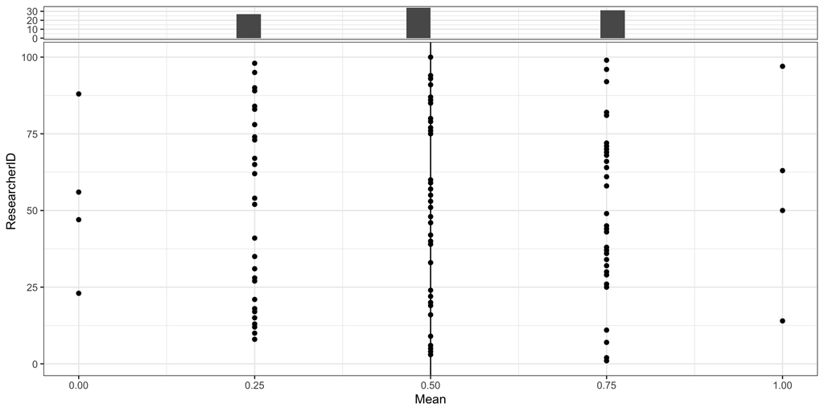

## 平均値: N = 30

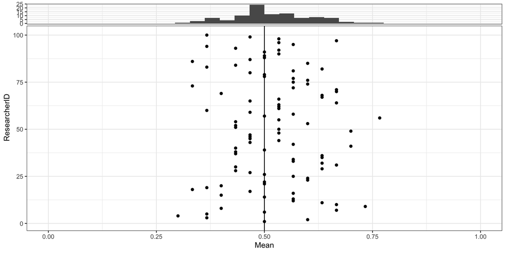

## くじ引き

- どのようなデータを用いることができるのか？ $=$ 確率的(くじ引き)で決定
  - データから生成されるモデルも確率的に決定
- 二乗誤差を評価指標として用いるのであれば、大はずしを減らしたい
  - 事例集計が有効

## 事例の集計

- ランダムに抽出されたデータであれば、事例数が増えれば増えるほど、サンプル平均値は母平均に近づいていく
  - **平均値**に観察されない要因が与える影響を緩和できる!!!
  - 運悪く的外れなモデルを用いてしまうリスクの緩和

## 平均値: N = 1000

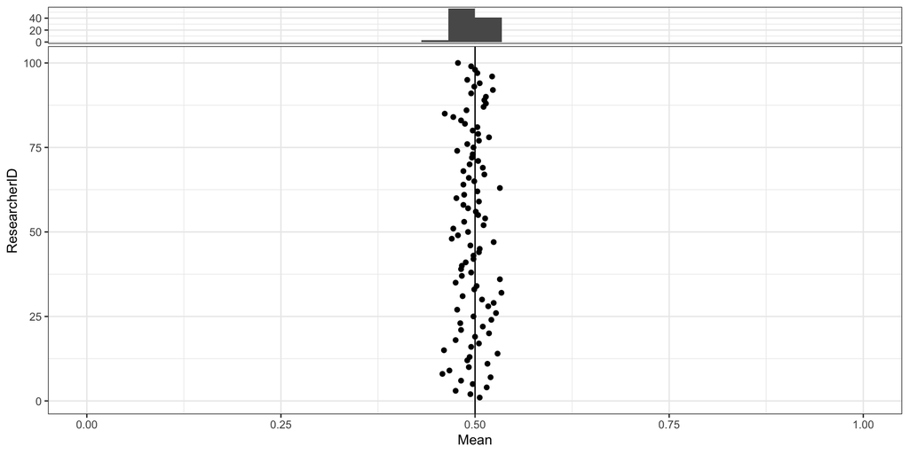

## 予測モデルの推定:

- ２つの選択肢
  - 全事例の単純平均
  - 平日/休日ごとの平均 (丸暗記 / １回のみ分割を行う決定木)

## トレードオフ

- 単純平均は
  - 兵員多くの事例を集約でき、観察されない要素の偏りを緩和できる
  - 観察できる情報(曜日)を未活用

## サブグループ平均値: N = 30

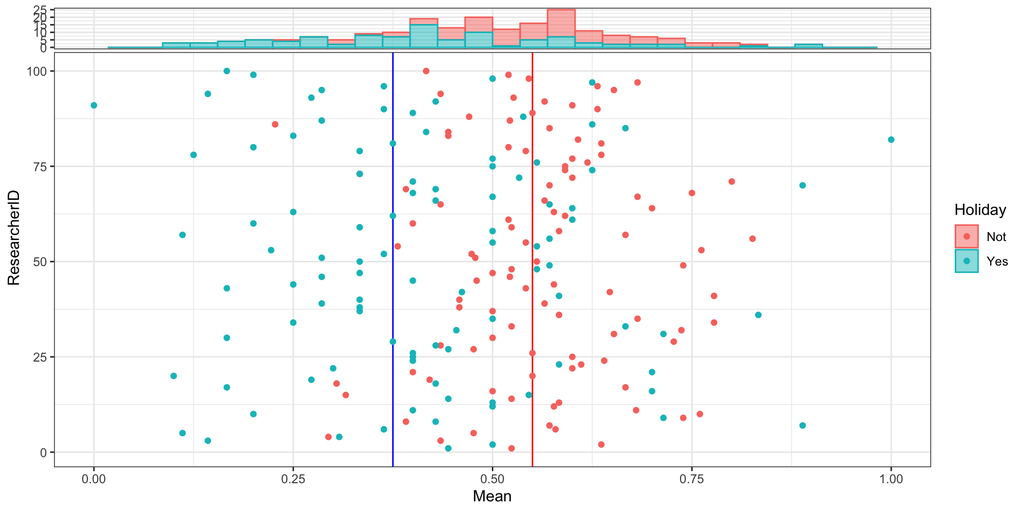

## サンプルサイズの恩恵

- 一般に、サンプルサイズが大きければ、サンプル分割の弊害は減少する
  - データ分析版: 限界生産性低減
- より細かくサンプル分割 (複雑なモデル) しても、観察できない要因の偏りを軽減できる

## サンプル増加: N = 1000

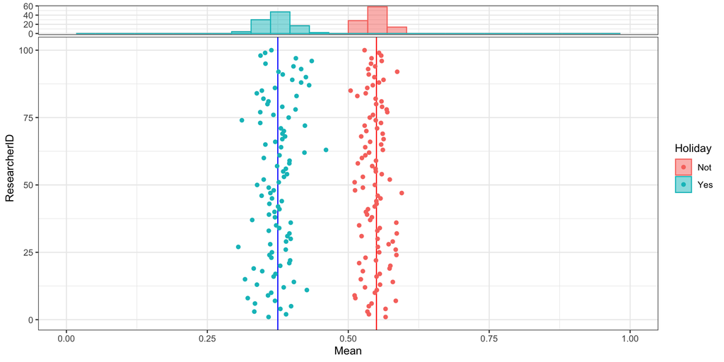

## まとめ: データへの適合 VS 事例集計

- 一般化できる含意: $X$ の持つ情報を完全活用するためには、
  - 事例集計により、データが偶然もった観察できない要因の偏りを緩和したい
- 複雑なモデル ($X$の情報をより活用したモデル)は、事例が少ないと
  - データへ適合が改善するが、データが偶然もった特徴も反映してしまう
  - 過剰適合/過学習